# Simulation Project

STAT 420, Summer 2019, Janda - joshlj2

## Simulation 1 - Significance of Regression

**Introduction**  
The reasoning behind this simulation is to show how the significance of regression test is useful. This test allows us to test whether our regression model holds any significant explanatory power. Overall, the test allows us to see if there is a linear relationship between any of the variables and the variable we are predicting.  
In this exact simulation we will be utilizing the significance of regression test to test between a significant model and a non-significant model. The significant model will consist of four parameters, an intercept which will be equal to three and three variables (so three coefficients). Each coefficient will be equal to one. Our insignificant model will consist of one parameter, an intercept equal to three. Our insignificant model removes the three variables and states that their true coefficients are actually equal to zero. We will be performing the significance of regression test on each model, in each simulation.  
I will be simulating a sample size of n=25 with three levels of sigma for the error term. I will then simulate 2,500 regression models for each sample with each level of sigma. This will equal to a total of 15,000 simulations of y. Each simulation I will conduct the significance of regression test for each model.

**Methods**

```r
library(readr)
study1 = read_csv("study_1.csv")
set.seed(19981127)
#sigma level 1, sigma = 1
sim1_sigma1 = data.frame(#initialize dataframe for level 1 sigma
                          full_ftest = rep(0, 2500),
                          full_pval = rep(0, 2500),
                          full_rsq = rep(0, 2500),
                          red_ftest = rep(0, 2500),
                          red_pval = rep(0, 2500),
                          red_rsq = rep(0, 2500)
)

for (i in 1:2500) {#sigma level 1
  epsilon = rnorm(25, mean = 0, sd = 1) #generate error terms
  study1$y = 3 + 1*study1$x1 + 1*study1$x2 + 1*study1$x3 + epsilon #generate y values for full model
  full_mod = lm(y ~ x1 + x2 + x3, data=study1) #full (significant) model
  sim1_sigma1$full_ftest[i] = summary(full_mod)$fstatistic[[1]]
  sim1_sigma1$full_pval[i] = pf(summary(full_mod)$fstatistic[[1]], 3, 21, lower.tail=FALSE)
  sim1_sigma1$full_rsq[i] = summary(full_mod)$r.squared

  study1$y = 3 + epsilon
  red_mod = lm(y ~ x1 + x2 + x3, data=study1)
  sim1_sigma1$red_ftest[i] = summary(red_mod)$fstatistic[[1]]
  sim1_sigma1$red_pval[i] = pf(summary(red_mod)$fstatistic[[1]], 3, 21, lower.tail=FALSE)
  sim1_sigma1$red_rsq[i] = summary(red_mod)$r.squared

}

sim1_sigma2 = data.frame(#initialize dataframe for level 2 sigma
                          full_ftest = rep(0, 2500),
                          full_pval = rep(0, 2500),
                          full_rsq = rep(0, 2500),
                          red_ftest = rep(0, 2500),
                          red_pval = rep(0, 2500),
                          red_rsq = rep(0, 2500)
)

for (i in 1:2500) {#sigma level 2
  epsilon = rnorm(25, mean = 0, sd = 5) #generate error terms
  study1$y = 3 + 1*study1$x1 + 1*study1$x2 + 1*study1$x3 + epsilon #generate y values for full model
  full_mod = lm(y ~ x1 + x2 + x3, data=study1) #full (significant) model
  sim1_sigma2$full_ftest[i] = summary(full_mod)$fstatistic[[1]]
  sim1_sigma2$full_pval[i] = pf(summary(full_mod)$fstatistic[[1]], 3, 21, lower.tail=FALSE)
  sim1_sigma2$full_rsq[i] = summary(full_mod)$r.squared

  study1$y = 3 + epsilon
  red_mod = lm(y ~ x1 + x2 + x3, data=study1)
  sim1_sigma2$red_ftest[i] = summary(red_mod)$fstatistic[[1]]
  sim1_sigma2$red_pval[i] = pf(summary(red_mod)$fstatistic[[1]], 3, 21, lower.tail=FALSE)
  sim1_sigma2$red_rsq[i] = summary(red_mod)$r.squared

}

sim1_sigma3 = data.frame(#initialize dataframe for level 3 sigma
                          full_ftest = rep(0, 2500),
                          full_pval = rep(0, 2500),
                          full_rsq = rep(0, 2500),
                          red_ftest = rep(0, 2500),
                          red_pval = rep(0, 2500),
                          red_rsq = rep(0, 2500)
)

for (i in 1:2500) {#sigma level 3
  epsilon = rnorm(25, mean = 0, sd = 10) #generate error terms
  study1$y = 3 + 1*study1$x1 + 1*study1$x2 + 1*study1$x3 + epsilon #generate y values for full model
  full_mod = lm(y ~ x1 + x2 + x3, data=study1) #full (significant) model
  sim1_sigma3$full_ftest[i] = summary(full_mod)$fstatistic[[1]]
  sim1_sigma3$full_pval[i] = pf(summary(full_mod)$fstatistic[[1]], 3, 21, lower.tail=FALSE)
  sim1_sigma3$full_rsq[i] = summary(full_mod)$r.squared

  study1$y = 3 + epsilon
  red_mod = lm(y ~ x1 + x2 + x3, data=study1)
  sim1_sigma3$red_ftest[i] = summary(red_mod)$fstatistic[[1]]
  sim1_sigma3$red_pval[i] = pf(summary(red_mod)$fstatistic[[1]], 3, 21, lower.tail=FALSE)
  sim1_sigma3$red_rsq[i] = summary(red_mod)$r.squared

}
```

**Graphical Results**  
**Figure 1 - $\sigma$ = 1**

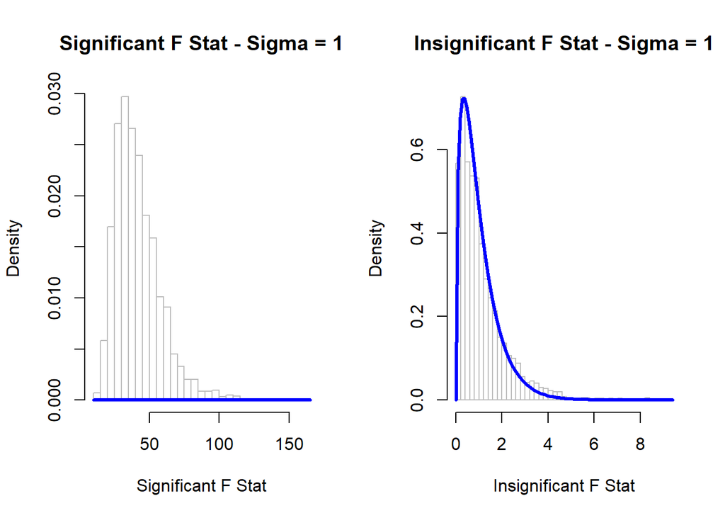

```r
##BEGIN PLOTTING CODE

##Sigma = 1##

#F Statistic Distributions#

par(mfrow = c(1, 2))
hist(
      sim1_sigma1$full_ftest,
      main = 'Significant F Stat - Sigma = 1',
      border = 'grey',
      xlab = 'Significant F Stat',
      prob = TRUE,
      breaks = 40
     )
x = sim1_sigma1$full_ftest
curve(df(x, 3, 2496), col = 'blue', add = TRUE, lwd = 3)

hist(
      sim1_sigma1$red_ftest,
      main = 'Insignificant F Stat - Sigma = 1',
      border = 'grey',
      xlab = 'Insignificant F Stat',
      prob = TRUE,
      breaks = 40
     )
x = sim1_sigma1$red_ftest
curve(df(x, 3, 2496), col = 'blue', add = TRUE, lwd = 3)
```

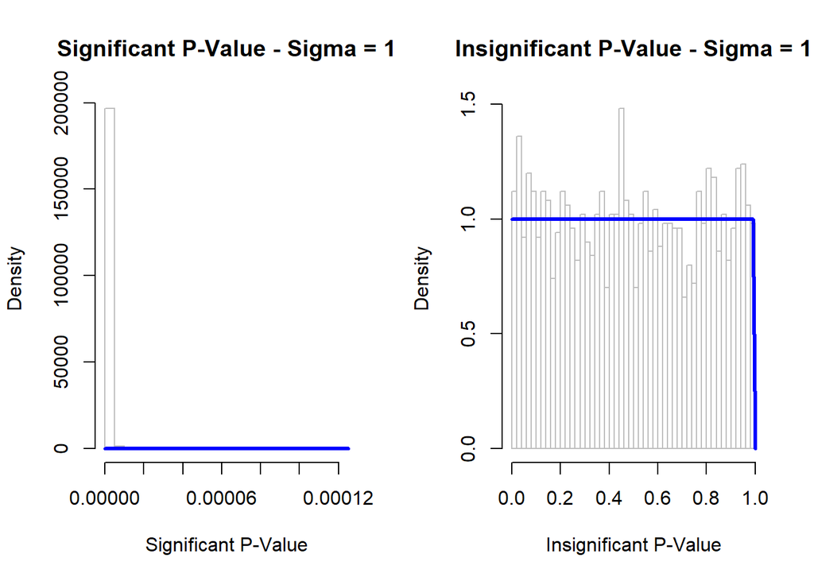

```r
#P-Value Distributions#
par(mfrow = c(1, 2))
hist(
      sim1_sigma1$full_pval,
      main = 'Significant P-Value - Sigma = 1',
      border = 'grey',
      xlab = 'Significant P-Value',
      prob = TRUE,
      breaks = 40
     )
x = sim1_sigma1$full_pval
curve(dunif(x), col='blue', add=TRUE, lwd=3)
hist(
      sim1_sigma1$red_pval,
      main = 'Insignificant P-Value - Sigma = 1',
      border = 'grey',
      xlab = 'Insignificant P-Value',
      prob = TRUE,
      breaks = 40
     )
x = sim1_sigma1$red_pval
curve(dunif(x), col='blue', add=TRUE, lwd=3)
```

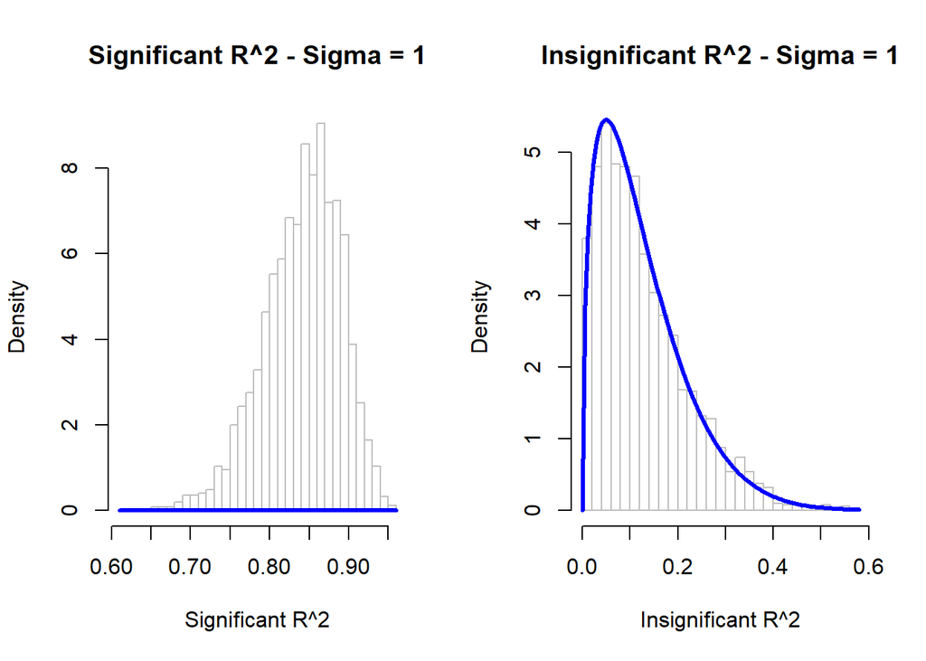

```r
#R-Squared Distributions#
par(mfrow = c(1, 2))
hist(
      sim1_sigma1$full_rsq,
      main = 'Significant R^2 - Sigma = 1',
      border = 'grey',
      xlab = 'Significant R^2',
      prob = TRUE,
      breaks = 40
     )
x = sim1_sigma1$full_rsq
curve(dbeta(x, 3/2, 21/2), col='blue', add=TRUE, lwd=3)
hist(
      sim1_sigma1$red_rsq,
      main = 'Insignificant R^2 - Sigma = 1',
      border = 'grey',
      xlab = 'Insignificant R^2',
      prob = TRUE,
      breaks = 40
     )
x = sim1_sigma1$red_rsq
curve(dbeta(x, 3/2, 21/2), col='blue', add=TRUE, lwd=3)
```

**Figure 2 - $\sigma$ = 5**

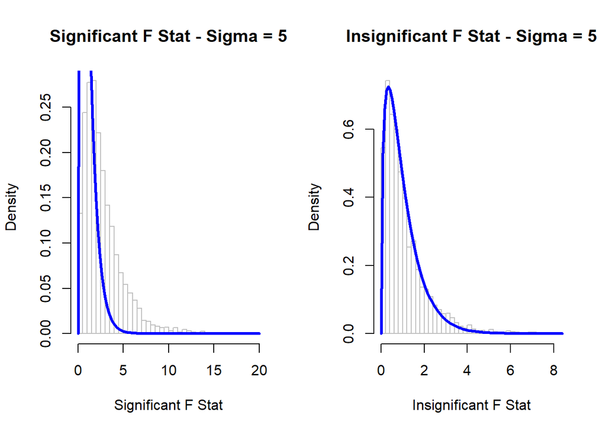

```r
##Sigma = 5##

#F Statistic Distributions#

par(mfrow = c(1, 2))
hist(
      sim1_sigma2$full_ftest,
      main = 'Significant F Stat - Sigma = 5',
      border = 'grey',
      xlab = 'Significant F Stat',
      prob = TRUE,
      breaks = 40
     )
x = sim1_sigma2$full_ftest
curve(df(x, 3, 2496), col = 'blue', add = TRUE, lwd = 3)

hist(
      sim1_sigma2$red_ftest,
      main = 'Insignificant F Stat - Sigma = 5',
      border = 'grey',
      xlab = 'Insignificant F Stat',
      prob = TRUE,
      breaks = 40
     )
x = sim1_sigma2$red_ftest
curve(df(x, 3, 2496), col = 'blue', add = TRUE, lwd = 3)
```

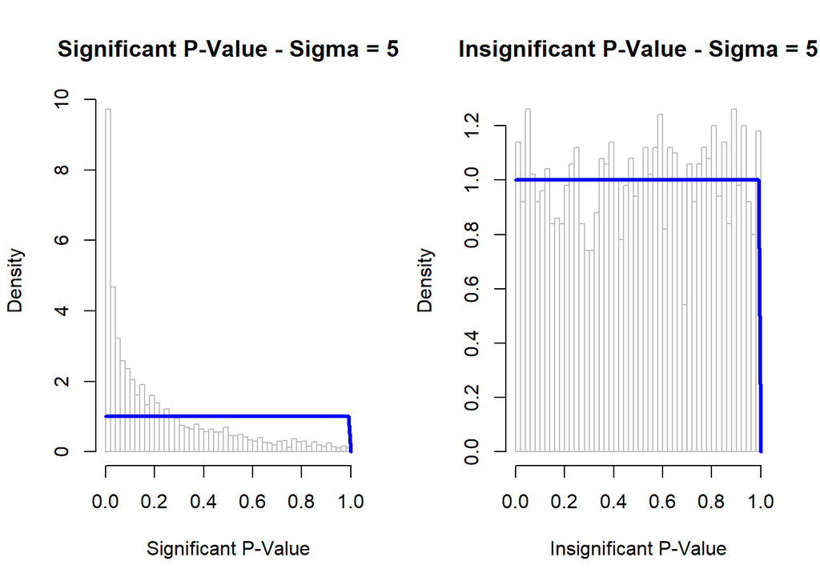

```r
#P-Value Distributions#
par(mfrow = c(1, 2))
hist(
      sim1_sigma2$full_pval,
      main = 'Significant P-Value - Sigma = 5',
      border = 'grey',
      xlab = 'Significant P-Value',
      prob = TRUE,
      breaks = 40
     )
x = sim1_sigma2$full_pval
curve(dunif(x), col='blue', add=TRUE, lwd=3)
hist(
      sim1_sigma2$red_pval,
      main = 'Insignificant P-Value - Sigma = 5',
      border = 'grey',
      xlab = 'Insignificant P-Value',
      prob = TRUE,
      breaks = 40
     )
x = sim1_sigma2$red_pval
curve(dunif(x), col='blue', add=TRUE, lwd=3)
```

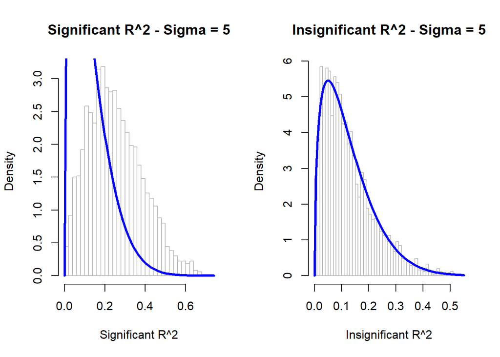

```r
#R-Squared Distributions#
par(mfrow = c(1, 2))
hist(
      sim1_sigma2$full_rsq,
      main = 'Significant R^2 - Sigma = 5',
      border = 'grey',
      xlab = 'Significant R^2',
      prob = TRUE,
      breaks = 40
     )
x = sim1_sigma2$full_rsq
curve(dbeta(x, 3/2, 21/2), col='blue', add=TRUE, lwd=3)
hist(
      sim1_sigma2$red_rsq,
      main = 'Insignificant R^2 - Sigma = 5',
      border = 'grey',
      xlab = 'Insignificant R^2',
      prob = TRUE,
      breaks = 40
     )
x = sim1_sigma2$red_rsq
curve(dbeta(x, 3/2, 21/2), col='blue', add=TRUE, lwd=3)
```

**Figure 3 - $\sigma$ = 10**

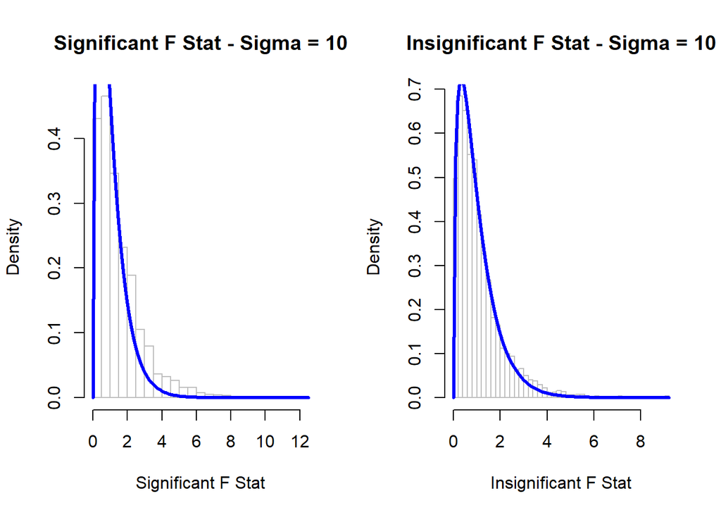

```r
##Sigma = 10##

#F Statistic Distributions#

par(mfrow = c(1, 2))
hist(
      sim1_sigma3$full_ftest,
      main = 'Significant F Stat - Sigma = 10',
      border = 'grey',
      xlab = 'Significant F Stat',
      prob = TRUE,
      breaks =  40
     )
x = sim1_sigma3$full_ftest
curve(df(x, 3, 2496), col = 'blue', add = TRUE, lwd = 3)

hist(
      sim1_sigma3$red_ftest,
      main = 'Insignificant F Stat - Sigma = 10',
      border = 'grey',
      xlab = 'Insignificant F Stat',
      prob = TRUE,
      breaks = 40
     )
x = sim1_sigma3$red_ftest
curve(df(x, 3, 2496), col = 'blue', add = TRUE, lwd = 3)
```